# Simple Benchmark of GLM

[Link to Rendered html view](https://htmlpreview.github.io/?https://github.com/lorentzenchr/notebooks/blob/master/bench_GLM.html).

Here, we want to compare different GLM implementations in R and Python on the same dataset, namely the french MTPL dataset https://www.openml.org/d/41214. This dataset is also available on http://cas.uqam.ca/ as R package CASdatasets, but the data may change from version to version.

```r
library(bench)
library(ggplot2)
library(glmnet)
library(knitr)
library(MetricsWeighted)
library(OpenML)
library(tidyverse)
```

## Load and prepare data

We load and prepare the data. As we are not interested in model comparison, we can use the whole data for mode training. We also create the design matrix `X` for glmnet, which does not understand a formula. In addition, this makes working with Python implemetations particular simpler.

```r
df <- getOMLDataSet(data.id = 41214L)
df <- tibble(df$data)

df_train <- df %>%
  mutate(Freq = ClaimNb / Exposure,
         Area = factor(Area),
         Region = factor(Region),
         VehBrand = factor(VehBrand),
         VehGas = factor(VehGas),
         logDensity = log(Density)
         )

y <- df_train$Freq
w <- df_train$Exposure
X <- model.matrix(Freq ~ DrivAge + VehAge + VehPower
                  + logDensity
                  + Region + VehBrand + VehGas,
                  data = df_train)
```

We have a design matrix with 678013 rows and 37 columns.

## R GLM Implementations

It is hard to compare glm and glmnet as they measure the precision differently:

- glm uses epsilon: The iterations converge when |dev - dev_{old}|/(|dev| + 0.1) < epsilon.
- glmnet uses thresh: Each inner coordinate-descent loop continues until the maximum change in the objective after any coefficient update is less than thresh times the null deviance.

We use the default value `epsilon = 1e-8` and set `thres = 1e-7`, i.e. the largest value for which the objective is smaller or equal the glm one.

```r
glm_control <- glm.control(epsilon = 1e-8)  # the default

run_glm <- function(){
  glm(Freq ~ DrivAge + VehAge + VehPower
      + logDensity
      + Region + VehBrand + VehGas,
      data = df_train,
      weights = w,
      family = quasipoisson(),
      control = glm_control
      )
}

run_glm_matrix <- function(){
  glm.fit(X, y, weights = w,
          family = quasipoisson(),
          control = glm_control
          )
}

run_glmnet <- function(){
  glmnet(X, y, weights = w,
         family = "poisson",
         lambda = 0,
         standardize = FALSE,
         thresh = 1e-7)
}
```

## Python GLM Implementations

We will use the `reticulate` package to run Python code from within R. Note that we are using the current master (v1.17 unreleased) by installing via `remotes::install_github("rstudio/reticulate")`, see https://github.com/rstudio/reticulate/issues/831 for the reason why.

```r
library(reticulate)
use_virtualenv("~/github/python3_general", required = TRUE)
```

We could simply import the same dataset for Python with `fetch_openml(data_id=41214, as_frame=True).frame` from `sklearn.datasets.fetch_openml`. But with `reticulate`, it is even simpler to access R objects directly, e.g. `r.df_train`, `r.X`, etc. This way, we even have the same preprocessed data for sure, i.e. the design matrix.

```python
import numpy as np
import pandas as pd
from sklearn.base import clone
from sklearn.linear_model import PoissonRegressor
import statsmodels.api as sm


# Just to make sure that conversion between R and Python does not influence benchmarks.
X = r.X
y = r.y
w = r.w

# Note:
# 1) X already contains intercept, but scikit-learn estimator better works
#    with setting fit_intercept=True, as it initializes with better values.
# 2) We could reuse sklearn_glm several times and therefore set
#    warm_start=False in order to have a fair comparison. Instead, we use
#    clone(sklearn_glm) inside run_sklearn
sklearn_glm = PoissonRegressor(alpha=0, fit_intercept=True, max_iter=1000,
                               tol=1e-5, warm_start=False)
sm_glm = sm.GLM(y, X, var_weights=w, family=sm.families.Poisson())
```

But we benchmark in R:

```r
run_sklearn <- function(){
  py_run_string("clone(sklearn_glm).fit(X[:, 1:], y, sample_weight=w)")
}
run_statsmodels <- function(){
  py_run_string("sm_glm.fit(tol=1e-8)")
}
```

## Check Average Poisson Deviance

We compare the resulting in-sample objective, namely the average poisson deviance in order to be sure, we compared apples with apples, i.e. have fitted with the same target precision.

```r
res_glm <- run_glm()
res_glmnet <- run_glmnet()
py_run_string("res_sklearn = clone(sklearn_glm).fit(X[:, 1:], y, sample_weight=w)")
py_run_string("res_sm = sm_glm.fit(tol=1e-8)")

# Compare training loss
objective_table <- tibble(
  estimator = c("glm", "glmnet", "scikit-learn", "statsmodels"),
  poisson_deviance = c(
    deviance_poisson(y, predict(res_glm, df_train, type = "response")),
    deviance_poisson(y, predict(res_glmnet, X, type = "response")),
    deviance_poisson(y, py$res_sklearn$predict(X[, -1])),
    deviance_poisson(y, py$res_sm$predict(X))
  )
)

# options(pillar.sigfig = 6)
# print(objective_table)
kable(objective_table, caption = "Poisson Deviance", digits = 6)
```

Poisson Deviance

| estimator | poisson_deviance |
| --- | --- |
| glm | 2.401500 |
| glmnet | 2.401489 |
| scikit-learn | 2.401480 |
| statsmodels | 2.401500 |

## Run Benchmak—Finally

And here comes the benchmark:

```r
lb <- bench::mark(
  run_glm(),
  run_glm_matrix(),
  run_glmnet(),
  run_sklearn(),
  run_statsmodels(),
  check = FALSE,
  memory = FALSE,
  min_iterations = 3
)
# summary(lb)
kable(lb, caption = "Benchmark Results")
```

Benchmark Results

| expression | min | median | itr/sec | mem_alloc | gc/sec | n_itr | n_gc | total_time | result | memory | time | gc |
| --- | --- | --- | --- | --- | --- | --- | --- | --- | --- | --- | --- | --- |
| run_glm() | 11.82s | 12.4s | 0.0801113 | NA | 0.6675941 | 3 | 25 | 37.45s | NULL | NULL | 13.22659, 12.39658, 11.82473 | 4, 3, 4, 4, 2, 2, 2, 2, 2 |
| run_glm_matrix() | 11.44s | 14.01s | 0.0740221 | NA | 0.4688067 | 3 | 19 | 40.53s | NULL | NULL | 11.43868, 15.07987, 14.00989 | 3, 4, 4, 2, 1, 2, 1, 1, 1 |
| run_glmnet() | 2.17s | 2.29s | 0.4426720 | NA | 0.1475573 | 3 | 1 | 6.78s | NULL | NULL | 2.290390, 2.316450, 2.170186 | 0, 1, 0, 0, 0, 0, 0, 0, 0 |
| run_sklearn() | 37.72s | 38.04s | 0.0259388 | NA | 0.0000000 | 3 | 0 | 1.93m | NULL | NULL | 37.72062, 38.03799, 39.89837 | 0, 0, 0, 0, 0, 0, 0, 0, 0 |
| run_statsmodels() | 7.18s | 7.56s | 0.1340809 | NA | 0.0000000 | 3 | 0 | 22.38s | NULL | NULL | 7.182545, 7.556927, 7.635084 | 0, 0, 0, 0, 0, 0, 0, 0, 0 |

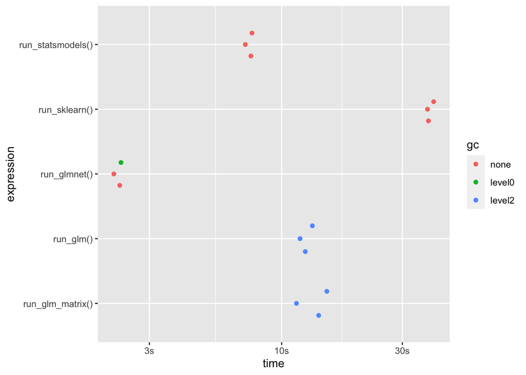

```r
autoplot(lb)
```

## Appendix

### Scikit-Learn Self Contained

If you want to create the same design matrix with scikit-learn as we did with R, you could use the following junk of code:

```python
import numpy as np
import pandas as pd
from sklearn.datasets import fetch_openml
from sklearn.pipeline import make_pipeline, Pipeline
from sklearn.preprocessing import FunctionTransformer, OneHotEncoder
from sklearn.compose import ColumnTransformer
from sklearn.linear_model import PoissonRegressor
from sklearn.metrics import mean_poisson_deviance


df = fetch_openml(data_id=41214, as_frame=True).frame
df["Freq"] = df["ClaimNb"] / df["Exposure"]

log_scale_transformer = make_pipeline(
    FunctionTransformer(np.log, validate=False)
)

linear_model_preprocessor = ColumnTransformer(
    [
        ("passthrough_numeric", "passthrough",
            ["DrivAge", "VehAge", "VehPower"]),
        ("logDensity", log_scale_transformer,
            ["Density"]),
        ("onehot_categorical", OneHotEncoder(drop='first', sparse=True),
            ["Region", "VehBrand", "VehGas"]),
    ],
    remainder="drop",
)

poisson_glm = Pipeline([
    ("preprocessor", linear_model_preprocessor),
    ("regressor", PoissonRegressor(alpha=0, max_iter=1000, tol=1e-5))
])

poisson_glm.fit(df, df["Freq"],
                regressor__sample_weight=df["Exposure"])

# create design matrix, but without intercept
poisson_glm[-2].transform(df)
```

### Statsmodels Design Matrix

Statsmodels uses patsy in order to process formulae just like R.

```python
import statsmodels.formula.api as smf

sm_glm = smf.glm("Freq ~ DrivAge + VehAge + VehPower"
                 " + logDensity"
                 " + Region + VehBrand + VehGas",
                 var_weights=w, family=sm.families.Poisson())
```